# Spawning damage and miss labels

Welcome to the last part of this JRPG series. We will wrap up with damage and miss labels.

[figure not shown]

We will first design two types of animated labels to instantiate them at runtime using a builder class. The builder class’s responsibility is to instantiate and initialize different kinds of labels.

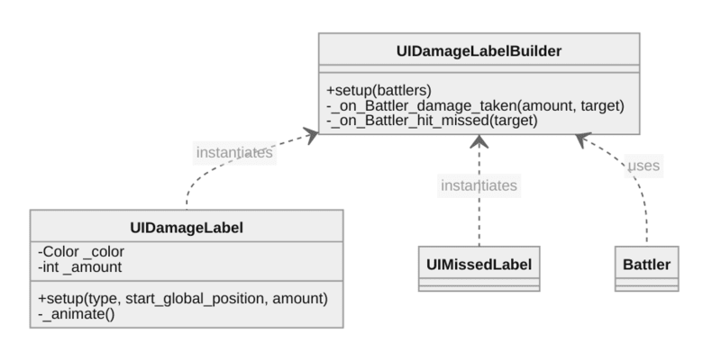

As with other user interface components, we will use a `setup()` function on the builder that receives an array of battlers to connect to their signals.

## Creating the label scenes

Let’s start with the label scenes because, as we saw, they are a dependency on the builder.

We will use two approaches for animation: the miss label will use an animation player because it will only move upwards in a predefined way. We will use tweens to throw the damage label randomly in a cone.

Having these different types of animations will give more visual weight to dealing or taking damage.

### The miss label

Let’s create the miss label first, as it’s the simplest of the two. Here’s what we’ll make.

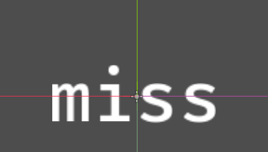

Create a scene with a position 2D named *UIMissedLabel* as its root, a *Label*, and an *AnimationPlayer*. Save it as `UIMissedLabel.tscn`.

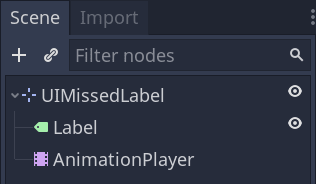

The *Position2D* node serves as a pivot for the *Label*. I use this setup because control nodes’ position is based on their top-left corner, even if you change the node’s pivot. Also, if we animate the *Label*’s position, we can still set the parent *UIMissedLabel*’s and the animation will be at an offset.

Set the *Label*’s text to “miss”, its *Custom Fonts -> Font* to `text_extralarge.tres`.

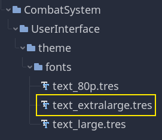

Then, move the node up so the text is right above the viewport’s origin.

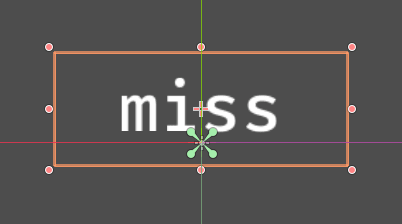

Remember to animate the *Label* node’s *Rect Position* to move it up, **not** the *UIMissedLabel*.

We also want to destroy the node at the end of the animation as it’s no longer visible. Add a *Call Method* track and use a keyframe to call `queue_free()` at the end of the timeline. This way, we don’t need any script.

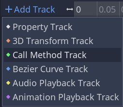

Your animation timeline should look like the following.

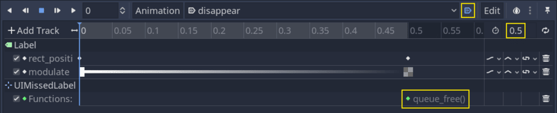

### The damage label

The damage label will animate in a random direction defined by a cone. This is why we need a different approach for this animation. Whenever an animation isn’t predefined, the *Tween* node is a tool of choice.

You can duplicate the `UIMissedLabel.tscn` scene you just created as we will use a similar setup. Name the copy `UIDamageLabel.tscn`, open it, rename its root node, and after ensuring you reset the node’s *Position* and *Modulate*, delete the *AnimationPlayer*.

You can also change the *Label*’s placeholder text.

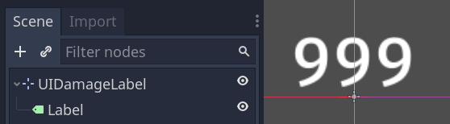

Add a *Tween* node as a child of *UIDamageLabel*.

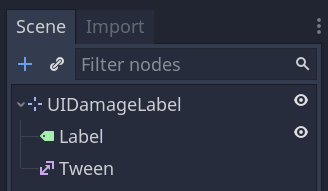

Attach a script to the `UIDamageLabel` node.

```
# Animated label displaying amounts of damage or healing.
class_name UIDamageLabel
extends Node2D

# We use the Types enum to control the Label's color, using the colors below.
enum Types { HEAL, DAMAGE }

const COLOR_TRANSPARENT := Color(1.0, 1.0, 1.0, 0.0)

# By exporting these two colors, we can edit them in the Inspector using a color picker. You could
# use constants instead.
export var color_damage := Color("#b0305c")
export var color_heal := Color("#3ca370")

# The actual color applied to the Label node's text via its `modulate` property.
var _color: Color setget _set_color
# This is the number displayed on the Label. We store it in a variable so we can call the `setup()`
# function below before adding the node to the tree, which is when we set the Label's text and start
# the animation.
var _amount := 0

onready var _label: Label = $Label
onready var _tween: Tween = $Tween


# Below, `type` should be a member of the `Types` enum.
func setup(type: int, start_global_position: Vector2, amount: int) -> void:
    # We start by updating the node's `global_position` and `_amount`
    global_position = start_global_position
    _amount = amount

    # Then, we assign it a color based on the `type`.
    match type:
        Types.DAMAGE:
            _set_color(color_damage)
        Types.HEAL:
            _set_color(color_heal)


func _ready() -> void:
    _label.text = str(_amount)
    _animate()


func _set_color(value: Color) -> void:
    _color = value
    # Once more, we need a setter for the `_color` property to trigger a change in the Label node.
    if not is_inside_tree():
        yield(self, "ready")
    _label.modulate = _color


# Animates the node flying up in a random direction.
func _animate() -> void:
    # We define a range of 120 degrees for the direction in which the node can fly.
    var angle := rand_range(-PI / 3.0, PI / 3.0)
    # And we calculate an offset vector from that.
    var offset := Vector2.UP.rotated(angle) * 60.0

    # The Tween node takes care of animating the Label's `rect_position` over 0.4 seconds. It's a
    # bit faster than the miss label and uses an ease-out so the animation feels dynamic.
    _tween.interpolate_property(
        _label,
        "rect_position",
        _label.rect_position,
        _label.rect_position + offset,
        0.4,
        Tween.TRANS_QUAD,
        Tween.EASE_OUT
    )
    # The fade-out animation starts after a 0.3 seconds delay and lasts 0.1 seconds.
    # This makes it so the Label quickly fades out and disappears at the end.
    _tween.interpolate_property(
        self, "modulate", modulate, COLOR_TRANSPARENT, 0.1, Tween.TRANS_LINEAR, Tween.EASE_IN, 0.3
    )
    _tween.start()
    # We finally wait for all tweens to complete before freeing the node.
    yield(_tween, "tween_all_completed")
    queue_free()
```

## Spawning labels with the builder object

We’re only missing the builder node to bring everything together.

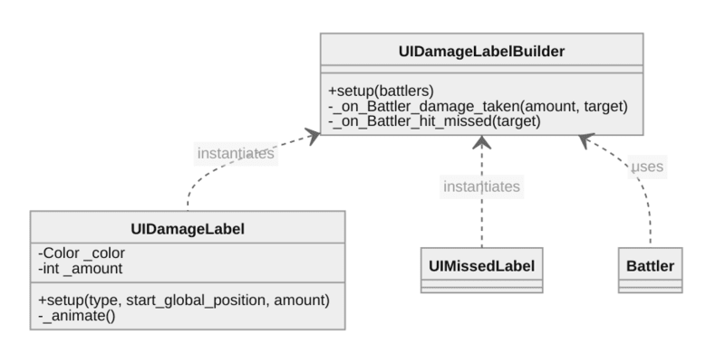

Create a new scene with a *Node2D* named *UIDamageLabelBuilder* and attach a script to it. It should connect to the battler’s `damage_taken` and `hit_missed` signals, and instantiate the corresponding animated labels when those events occur.

```
# Spawns labels that display damage, healing, or missed hits.
class_name UIDamageLabelBuilder
extends Node2D

# We preload the labels.
export var damage_label_scene: PackedScene = preload("UIDamageLabel.tscn")
export var miss_label_scene: PackedScene = preload("UIMissedLabel.tscn")


# In setup(), we connect to the Battler's `damage_taken` and `hit_missed` signals to instantiate the appropriate labels.
func setup(battlers: Array) -> void:
    for battler in battlers:
        battler.connect("damage_taken", self, "_on_Battler_damage_taken", [battler])
        battler.connect("hit_missed", self, "_on_Battler_hit_missed", [battler])


# When a battler takes damage, we instantiate a damage label.
func _on_Battler_damage_taken(amount: int, target: Battler) -> void:
    var label: UIDamageLabel = damage_label_scene.instance()
    # The setup() function takes care of changing the color, setting the text and placing it.
    label.setup(UIDamageLabel.Types.DAMAGE, target.battler_anim.get_top_anchor_global_position(), amount)
    # Adding the label as a child causes the animation to start.
    add_child(label)


func _on_Battler_hit_missed(target: Battler) -> void:
    var label = miss_label_scene.instance()
    add_child(label)
    # The miss label doesn't have a setup() function so we set its position by hand.
    label.global_position = target.battler_anim.get_top_anchor_global_position()
```

We need to instantiate it in the *CombatDemo* scene as a child of our *UI* canvas layer and call its `setup()` function.

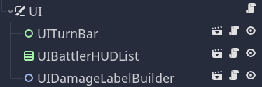

Open *CombatDemo*’s script and add the following lines to it.

```
onready var ui_damage_label_builder := $UI/UIDamageLabelBuilder

func _ready() -> void:
    #...
    ui_damage_label_builder.setup(battlers)
```

With that, upon taking a hit, a label will appear.

[figure not shown]

And this completes our JRPG combat demo.